# STAT/MATH 495: Problem Set 03

Wayne Maumbe

2017-09-26

# Question

For both `data1` and `data2` tibbles (a tibble is a data frame with some [metadata](https://blog.rstudio.com/2016/03/24/tibble-1-0-0#tibbles-vs-data-frames) attached):

- Find the splines model with the best out-of-sample predictive ability.
- Create a visualizaztion arguing why you chose this particular model.
- Create a visualizaztion of this model plotted over the given $(x_i, y_i)$ points for $i=1,\ldots,n=3000$.
- Give your estimate $\widehat{\sigma}$ of $\sigma$ where the noise component $\epsilon_i$ is distributed with mean 0 and standard deviation $\sigma$.

## Sampling

### Data 1

Here we create 5 random distinct pseudotest samples from the dataset while keeping track of the corresponding pseudotraining set for each respective pseudotest. Note that all pseudoset samples from the data should be a fifth of the dataset and the pseudotraining set is made up of the remaining data.

```r
#randomly sample without replacement a fifth of the dataset
set.seed(5555)
ind1<-sample(nrow(data1),dim(data1)[1]/5, replace = FALSE)
ftest1<-data1[ind1,]
ftrain1<-data1[-ind1,] #the remaining data makes up the pseudotraining set.
fpstrain1<-ftrain1

#repeat process above ensuring that the sample is distinct from the first by sampling from the remaining data.
##(4)
ind2<-sample(nrow(ftrain1),dim(ftrain1)[1]/4, replace = FALSE)
ftest2<-ftrain1[ind2,]
ftrain2<-ftrain1[-ind2,]
fpstrain2<-bind_rows(ftest1, ftrain2) #collect remaining data to create pseudotraining set

#process is repeated here until all five combinationations are made.
##(5)
ind3<-sample(nrow(ftrain2),dim(ftrain2)[1]/3, replace = FALSE)
ftest3<-ftrain2[ind3,]
ftrain3<-ftrain2[-ind3,]
fpstrain3<-bind_rows(ftest1,ftest2,ftrain3)

##(6)
ind4<-sample(nrow(ftrain3),dim(ftrain3)[1]/2, replace = FALSE)
ftest4<-ftrain3[ind4,]
ftrain4<-ftrain3[-ind4,]
fpstrain4<-bind_rows(ftest1,ftest2,ftest3,ftrain4)

##(100)
ind5<-sample(nrow(ftrain4),dim(ftrain4)[1], replace = FALSE)
ftest5<-ftrain4[ind5,]
ftrain5<-ftrain4[-ind5,]
fpstrain5<-bind_rows(ftest1,ftest2,ftest3,ftest4)

#check if all values in the five pseudotest sets are distinct
kuona1<-bind_rows(ftest1,ftest2,ftest3,ftest4,ftest5)
kk1<-distinct(kuona1)
dim(kk1)[1]
```

```
## [1] 3000
```

### Data 2

The sampling process discribed above is applied on dataset data2.

```r
#use the same sampling algorithm
set.seed(369)
ind1<-sample(nrow(data2),dim(data2)[1]/5, replace = FALSE)
stest1<-data2[ind1,]
strain1<-data2[-ind1,]
spstrain1<-strain1

##(400)
ind2<-sample(nrow(strain1),dim(strain1)[1]/4, replace = FALSE)
stest2<-strain1[ind2,]
strain2<-strain1[-ind2,]
spstrain2<-bind_rows(stest1, strain2)


##(500)
ind3<-sample(nrow(strain2),dim(strain2)[1]/3, replace = FALSE)
stest3<-strain2[ind3,]
strain3<-strain2[-ind3,]
spstrain3<-bind_rows(stest1,stest2,strain3)

##(600)
ind4<-sample(nrow(strain3),dim(strain3)[1]/2, replace = FALSE)
stest4<-strain3[ind4,]
strain4<-strain3[-ind4,]
spstrain4<-bind_rows(stest1,stest2,stest3,strain4)

##(700)
ind5<-sample(nrow(strain4),dim(strain4)[1], replace = FALSE)
stest5<-strain4[ind5,]
strain5<-strain4[-ind5,]
spstrain5<-bind_rows(stest1,stest2,stest3,stest4)

kuona2<-bind_rows(stest1,stest2,stest3,stest4,stest5)
kk2<-distinct(kuona2)
```

## Finding optimal degrees of freedom

First I made a function that finds the optimum degrees of freedom given a test and training dataset. This function will return a plot showing the weight of each degree of freedom according to the RSME value. Here we clearly find the optimum degree of freedom which will have the lowest RSME.

```r
opt<-function(train, test){
  n=99 #maximum possible df
  mat <- mat.or.vec(n,1) # makes empty vector for keeping track of the minimum rsme and df
for (i in 2:n) { # loops goes through all possible df from the least df=2 up to n
  smodel <- smooth.spline(x=train$x, y=train$y, df=i)
  tidymodel<-smodel%>%
    broom::augment()
  output<-predict(smodel, test$x)%>%
    tibble::as.tibble()
  rmse<- mean((test$y - output$y)^2)%>%
    sqrt()#calculates the rsme of the model fitted
   mat[i]<-rmse

}
  plot(mat[2:n], ylab ="RMSE", xlab = "df")
return(which(mat[2:n] == min(mat[2:n])))
}
#mat<-as.data.frame(mat)
#mat<-mat.or.vec(10,1)
#mat<-c(1,2,5,6,2,3,5,5,7,5)
```

The optimal df to use to fit a spline model on the dataset is the mean of all the optimal df calculated from the pseudotest and pseudotrain data.

```r
par(mfcol=c(1,5))
optfdf<-mean(c(opt(fpstrain1,ftest1),opt(fpstrain2,ftest2),opt(fpstrain3,ftest3),opt(fpstrain4,ftest4),opt(fpstrain5,ftest5)))
```

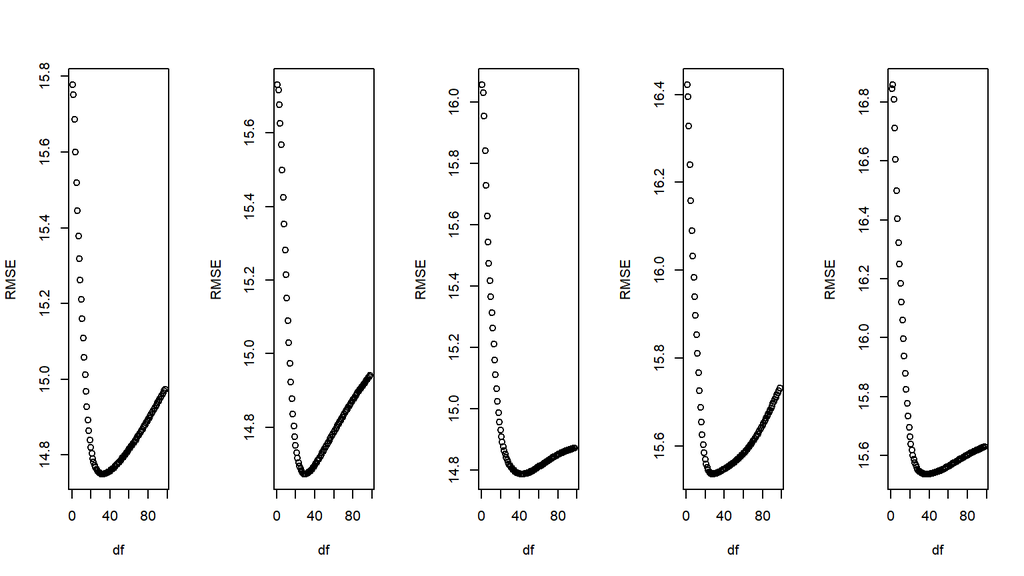

```r
#par(mfcol=c(1,5))
optsdf<-mean(c(opt(spstrain1,stest1),opt(spstrain2,stest2),opt(spstrain3,stest3),opt(spstrain4,stest4),opt(spstrain5,stest5)))
```

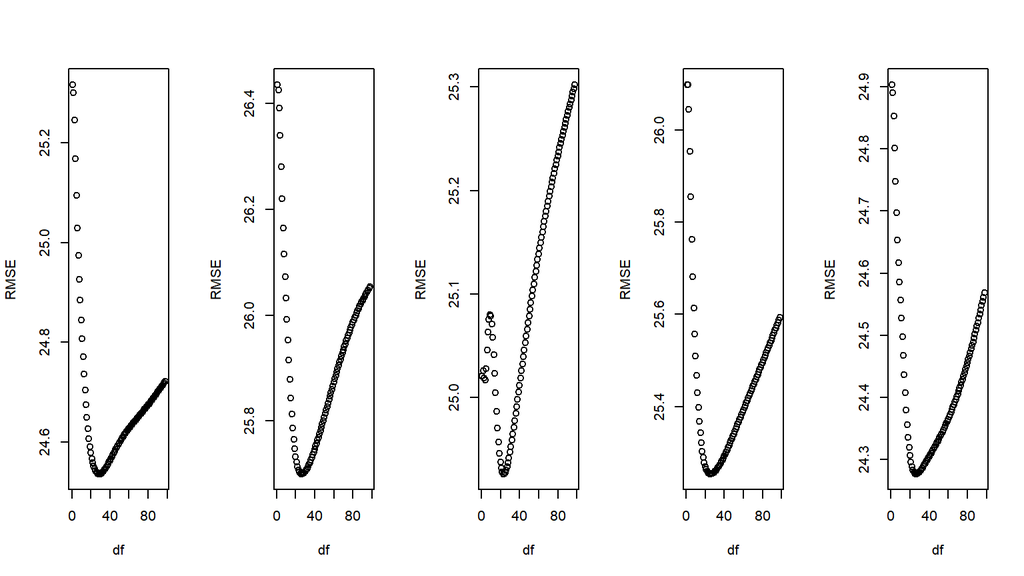

```r
optfdf
```

```
## [1] 34.4
```

```r
optsdf
```

```
## [1] 26.6
```

```r
smooth.spline(x=data1$x, y=data1$y, cv=T)
```

```
## Call:
## smooth.spline(x = data1$x, y = data1$y, cv = T)
##
## Smoothing Parameter  spar= 0.615802  lambda= 3.683003e-05 (13 iterations)
## Equivalent Degrees of Freedom (Df): 34.41222
## Penalized Criterion (RSS): 663196
## PRESS(l.o.o. CV): 226.2583
```

```r
smooth.spline(x=data2$x, y=data2$y, cv=T)
```

```
## Call:
## smooth.spline(x = data2$x, y = data2$y, cv = T)
##
## Smoothing Parameter  spar= 0.6703066  lambda= 9.129855e-05 (13 iterations)
## Equivalent Degrees of Freedom (Df): 27.66454
## Penalized Criterion (RSS): 1831557
## PRESS(l.o.o. CV): 622.0124
```

## Model fitting

### Visualization of model on pseudotest data from Data1

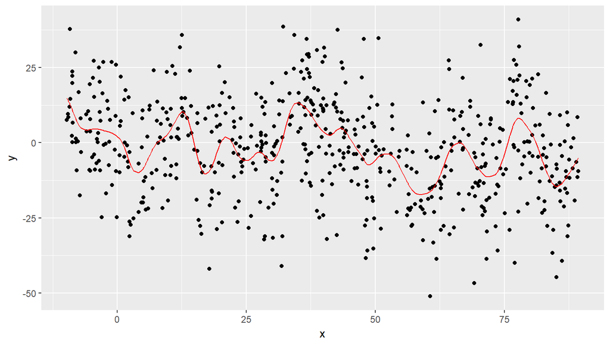

```r
tidy3 <- smooth.spline(x=ftest3$x,y=ftest3$y,df=optfdf) %>%
  broom::augment()
plot3 <- ggplot(tidy3, aes(x=x)) +
  geom_point(aes(y=y)) +
  geom_line(aes(y=.fitted), col="red")
plot3
```

## Applying model on Data1

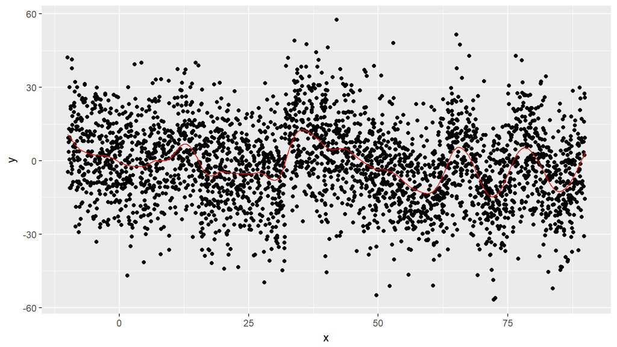

```r
tidy1 <- smooth.spline(x=data1$x,y=data1$y,df=optfdf) %>%
  broom::augment()
plot1 <- ggplot(tidy1, aes(x=x)) +
  geom_point(aes(y=y)) +
  geom_line(aes(y=.fitted), col="red")
plot1
```

### Visualization of model on pseudotest data from Data2

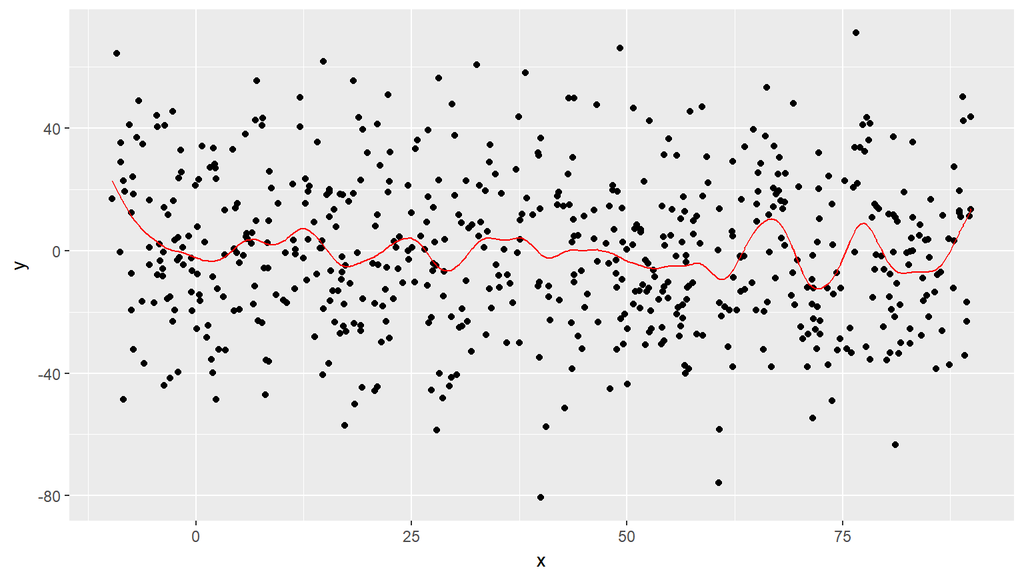

```r
tidy4 <- smooth.spline(x=stest3$x,y=stest3$y,df=optsdf) %>%
  broom::augment()
plot4 <- ggplot(tidy4, aes(x=x)) +
  geom_point(aes(y=y)) +
  geom_line(aes(y=.fitted), col="red")
plot4
```

## Applying model on Data2

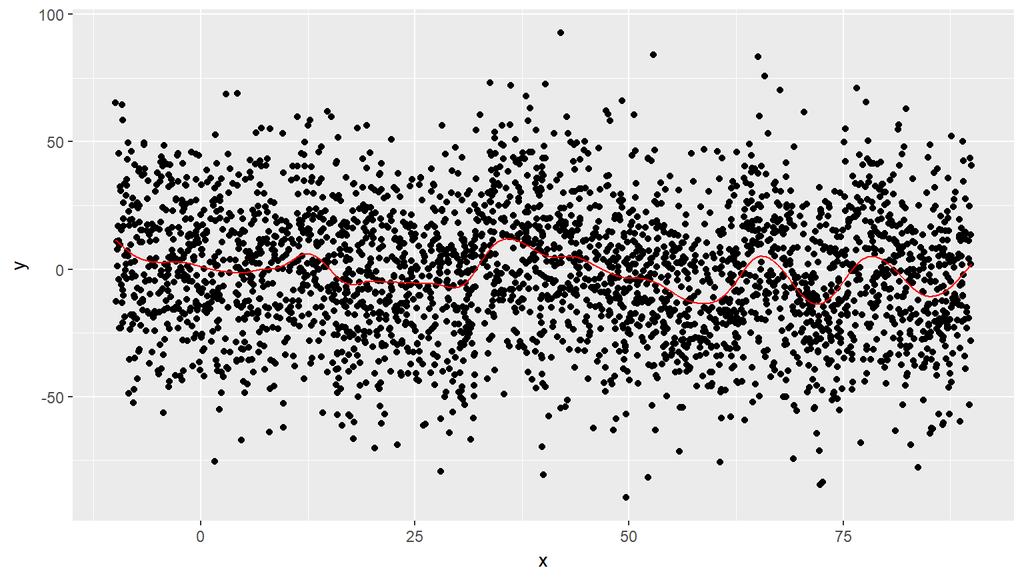

```r
tidy2 <- smooth.spline(x=data2$x,y=data2$y,df=optsdf) %>%
  broom::augment()
plot2 <- ggplot(tidy2, aes(x=x)) +
  geom_point(aes(y=y)) +
  geom_line(aes(y=.fitted), col="red")
plot2
```

## Estimating the distribution of noise

```r
err1<-data1$y - tidy1$.fitted
m1<-round(mean(err1,na.rm=T), 4)
s1<-round(sd(err1,na.rm=T),3)
err2<-data2$y - tidy2$.fitted
m2<-round(mean(err2,na.rm=T),4)
s2<-round(sd(err2,na.rm=T),3)
```

For data1 the the noise distribution can be estimated by mean 0.0031 and standard deviation 14.876 and data2 is estimated by 0.0055 and standard deviation 24.73.